# Salmon SNP Panel Introduction

```r
library(tidyverse)
library(data.table)
library(plotly)
library(leaflet)
```

### Our Dataset

This SNP panel contains 220,000 SNPs throughout the Atlantic Salmon genome. This panel was created by CIGENE as the SNPs most associated with differences between wild and aquaculture fish in Norway. Because the panel was developed for European salmon (which are genetically quite different from North American salmon) some SNPs were lost that are not present in North American Salmon. The result is ~170,000 SNPs at many sites throughout North America. For the purpose of this project, I have filtered the dataset to only incluse Eastern Newfoundland, within a half day’s drive of St. John’s:

```r
metadata <- fread("220kMetadata.csv")

nflEast <- metadata %>%
  filter(Dataset != "June 2023 Hybrid Samples") %>%
  filter(Longitude > -55.5)

leaflet(nflEast) %>%
  addTiles() %>%
  addCircleMarkers(lat=~Latitude, lng=~Longitude, popup =~location_name, color="salmon", radius=3)
```

[interactive chart not shown]

One of the most simple but powerful tools in genetic analysis is the principal component analysis (PCA). A PCA can show which rivers are most genetically similar to one another. The PCA is a dimensionality reduction technique which takes thousands of variables (in this case, SNPs) and pulls out the correlation between them. This works by plotting the data and drawing a line through it, then removing all correlation associated with that line–this becomes PC1. It then “rotates” the data and repeats the process, resulting in princial component values that are not correlated with one another and representing the extent of the variation in the data.

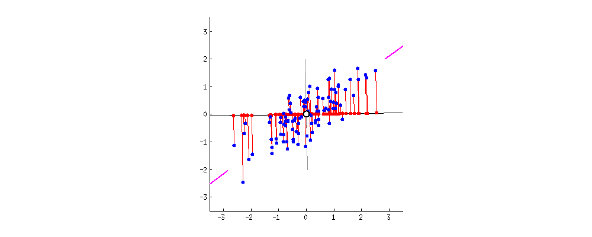

There are lots of online resources to learn more, but for now, the most important thing to know is that two points close to each other are more genetically similar. Each point represents an individual fish.

```r
write.table(nflEast %>%   select(c(FID, IID)), "nflEastsites.tsv", col.names = F, row.names = F, sep = "\t", quote = F)

system("/opt/miniconda3/bin/plink2 --allow-extra-chr --chr-set 29 --allow-no-sex --keep nflEastsites.tsv --pca --out nflEast --bfile ~/Desktop/Projects/GithubDownloads/GONE/Ssal.31.220K.mapped.June2023merge")


pca <- fread("nflEast.eigenvec") %>%
  rename("FID" = "#FID") %>%
  merge(metadata)

pcaPlot <- pca %>%
  ggplot(aes(x = PC1, y = PC2, colour = Rivername, label = Dataset)) +
  geom_point() +
  theme_bw()


ggplotly(pcaPlot)
```

[interactive chart not shown]

You’ll notice that populations from individual rivers cluster. This is because salmon are highly philopatric, with minimal straying between rivers. This makes them a great study species to understand local adaptation.

One thing that stands out to me is the Red Harbour River East Population. This river is distinct from others nearby (it is on the Burin peninsula), including Red Harbour River West, Big Salmonier, and Tides Brook, both of which are nearby! Interestingly, Red Harbour River West, Tides Brook, and Big Salmonier all are clustered so close to one another they could be the same population. I would definitely recommend looking for habitat differences between these sites.

For site selection of other sites, we should consider sites with the most “extreme” values on PC1-2. This will make sure we are working with the largest amount of variation possible, increasing our chances of finding detectable differences. These would be Branch River, Nonesuch River, Long Harbour, and Southeast Placentia River.

We can take a look at PCs 3-4 too, even though they represent a smaller amount of variation:

```r
pca2 <- fread("nflEast.eigenvec") %>%
  rename("FID" = "#FID") %>%
  merge(metadata) %>%
  ggplot(aes(x = PC3, y = PC4, colour = Rivername, label = Dataset)) +
  geom_point() +
  theme_bw()


ggplotly(pca2)
```

[interactive chart not shown]

It looks like all of the variation in PC4 is driven by one single point. On PC3, it looks like it is primarily pulling out variation between the Burin and Avalon peninsulas. Regardless, it seems like Southeast Placentia should be investigated further, as well as perhaps Northwest Brook or Cuslett Brook.

We should also check the PCA loadings, or the amoutn of variation represented by each axis:

```r
loadings <- fread("nflEast.eigenval")
rmarkdown::paged_table(loadings)
```

| V1 |
| --- |
| 29.56630 |
| 21.16470 |
| 19.08220 |
| 13.92330 |
| 12.86080 |
| 12.10140 |
| 11.28200 |
| 10.34040 |
| 9.53431 |
| 9.45185 |

To more visually represent this data, we can plot it on a map coloured by PC1. We expect that rivers closer to each other will be more similar (this is called “isolation by distance”), so any rivers that are geographically close but genetically different, or geographically far away but genetically similar, warrant firther investigation.

```r
library(viridis)
pc1Mean <- pca %>%
  group_by(FID) %>%
  summarize(PC1Mean = mean(PC1)) %>%
  merge(metadata) %>%
  select(-c(V1, IID)) %>%
  distinct()

pal <- leaflet::colorNumeric(
  palette = "viridis",
 # bin = 5,
  domain = pc1Mean$PC1Mean)

  leaflet(pc1Mean) %>%
  addProviderTiles(providers$CartoDB.Positron) %>%
  addCircleMarkers(lng=~Longitude, lat=~Latitude, radius = 5, fillColor = ~pal(PC1Mean), popup = ~Rivername, fillOpacity = 1, weight = .1, color = "black") %>%
  addLegend("bottomright", pal = pal, values = ~PC1Mean, title = "PC1 Mean Value")
```

[interactive chart not shown]

## Environmental Variation

Now that we have a better sense of where the most genetic variation is, we should look into environmental variation. Some places to start looking would be [geologic maps](https://www.gov.nl.ca/em/files/Geology-Map-of-Newfoundland.pdf), apps like iNaturalist to see if there are any species especially concentrated in only one area, and environmental datasets like bioclim. Below is a quick preview of some climate data. Because climate data has been investigated with this dataset (and found to be important), we should move beyond that.

The same way we can reduce genetic variation using a PCA, we can also reduce environmental variables. For this dataset, I used the CHELSA bioclimactic variables dataset. After conducting a PCA on 19 environmental variables, we can have a PC of environmental variation:

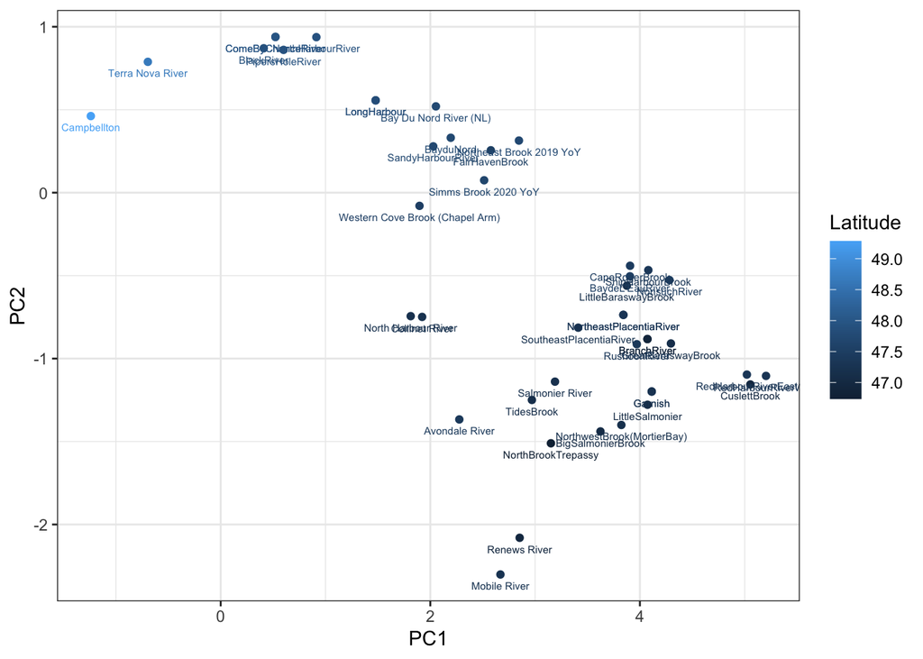

```r
envPC <- read.csv("chelsaBioclimScores.csv") %>%
  select(-(X)) %>%
    filter(Longitude > -55.5) %>%
  merge(metadata) %>%
  select(-c(IID, V1)) %>%
  distinct()

ggplot(envPC, aes(x = Comp.1, y = Comp.2, colour = Latitude, label = Rivername)) +
  geom_point() +
  geom_text(size = 2, vjust = 2) +
  theme_bw() +
labs(x = "PC1", y = "PC2")
```

```r
pal <- leaflet::colorNumeric(
  palette = "RdYlBu",
 # bin = 5,
  domain = envPC$Comp.1)

leaflet(envPC) %>%
  addProviderTiles(providers$CartoDB.Positron) %>%
  addCircleMarkers(lng=~Longitude, lat=~Latitude, radius = 6, fillColor = ~pal(Comp.1), popup = ~Rivername, fillOpacity = 1, weight = .1, color = "black") %>%
  addLegend("bottomright", pal = pal, values = ~Comp.1, title = "Environmental PC1 Value")
```

[interactive chart not shown]